# Analysing Sentences Backbone Communities

## Intertemporal cluster *7: voter, voters, voting, expected_utility*

The cluster gathers 28011 sentences from our corpus. It represents 10.34% of all the sentences selected over the whole period.

The community exists from 1900 to 2009.

The most recurring authors are Karni E. (158 sentences; 18 articles), Mark J. Machina (154 sentences; 10 articles), Robert Sugden (133 sentences; 24 articles), Jr. (127 sentences; 53 articles), Larry G. Epstein (119 sentences; 24 articles), David Schmeidler (112 sentences; 17 articles), Nehring K. (110 sentences; 9 articles), Walter Bossert (109 sentences; 14 articles), Alberto Alesina (106 sentences; 21 articles), Amartya Sen (105 sentences; 20 articles), David Kelsey (100 sentences; 12 articles), Massimo Marinacci (94 sentences; 8 articles), James M. Buchanan (92 sentences; 27 articles), Peter C. Fishburn (87 sentences; 25 articles), Chris Starmer (86 sentences; 12 articles).

The most recurring journals are Public Choice (2494 sentences; 817 articles), Econometrica (1340 sentences; 448 articles), Social Choice and Welfare (1160 sentences; 381 articles), Journal of Economic Theory (1156 sentences; 409 articles), The American Economic Review (1028 sentences; 501 articles), Theory and Decision (950 sentences; 269 articles).

### Top TF-IDF terms describing the community

| Token | TF-IDF |
| --- | --- |
| voter | 0.0102078 |
| voters | 0.0081658 |
| voting | 0.0071369 |
| expected_utility | 0.0054451 |
| vote | 0.0050796 |
| voter’s | 0.0046434 |
| electoral | 0.0046052 |
| election | 0.0045381 |
| median_voter | 0.0044600 |
| elections | 0.0040557 |
| votes | 0.0039453 |
| rational_voter | 0.0037591 |
| utility | 0.0036800 |
| preferences | 0.0035745 |
| vote_trading | 0.0031760 |
| marginal_utility | 0.0028101 |
| rational_voters | 0.0027629 |
| utility_theory | 0.0026823 |
| allais_paradox | 0.0026142 |
| voting_behavior | 0.0025392 |

### Top TF-IDF terms describing the different k-means clusters

#### Top terms 7_3_1900-1919: marginal_utility, horses, apple, marginal, marginal_utilities (1900-1919)

| Token | TF-IDF |
| --- | --- |
| marginal_utility | 0.0163763 |
| horses | 0.0138157 |
| apple | 0.0088758 |
| marginal | 0.0070294 |
| marginal_utilities | 0.0067938 |
| utility | 0.0065770 |
| wealthier | 0.0059172 |
| contemporaries | 0.0051174 |
| diminution | 0.0048041 |
| common_denominator | 0.0044446 |
| pressing | 0.0042843 |
| satisfaction | 0.0042627 |
| perfection | 0.0032992 |
| afford | 0.0031423 |
| final_utility | 0.0031314 |

#### Top terms 7_11_1930-1939: satisfactions, marginal_utility, utility, measurability, satisfaction (1930-1939)

| Token | TF-IDF |
| --- | --- |
| satisfactions | 0.0074723 |
| marginal_utility | 0.0074652 |
| utility | 0.0066936 |
| measurability | 0.0065997 |
| satisfaction | 0.0060752 |
| utility_concept | 0.0050207 |
| total_utility | 0.0048866 |
| utility_principle | 0.0041840 |
| final_utility | 0.0033472 |
| scales | 0.0028566 |
| marginal | 0.0023842 |
| prescriptions | 0.0022518 |
| utilities | 0.0022496 |
| utility_theory | 0.0022200 |
| measurement | 0.0022176 |

#### Top terms 7_9_1940-1949: interpersonal, ordinal, utility, utility_concept, cardinal_utility (1940-1949)

| Token | TF-IDF |
| --- | --- |
| interpersonal | 0.0071348 |
| ordinal | 0.0059090 |
| utility | 0.0057501 |
| utility_concept | 0.0056935 |
| cardinal_utility | 0.0053561 |
| cardinal | 0.0050190 |
| public_utility | 0.0048486 |
| ordinal_utility | 0.0046522 |
| interpersonal_comparison | 0.0043034 |
| interpersonal_utility | 0.0038936 |
| satisfaction | 0.0038752 |
| utility_comparisons | 0.0038054 |
| comparisons | 0.0037827 |
| real_income | 0.0036315 |
| interpersonal_comparisons | 0.0035664 |

#### Top terms 7_13_1950-1959: cardinal, ordinal, utility, measurability, marginal_utility (1950-1959)

| Token | TF-IDF |
| --- | --- |
| cardinal | 0.0096604 |
| ordinal | 0.0080427 |
| utility | 0.0079008 |
| measurability | 0.0073133 |
| marginal_utility | 0.0060040 |
| cardinal_utility | 0.0057858 |
| ordinal_utility | 0.0046905 |
| utility_theory | 0.0045686 |
| measurable_utility | 0.0040182 |
| utilities | 0.0036800 |
| measurable | 0.0034574 |
| diminishing_marginal | 0.0031343 |
| utility_analysis | 0.0030823 |
| diminishing | 0.0026331 |
| measurement | 0.0026276 |

#### Top terms 7_15_1950-1959: preferences, preferential, preference, indifference, indifferences (1950-1959)

| Token | TF-IDF |
| --- | --- |
| preferences | 0.0085455 |
| preferential | 0.0069878 |
| preference | 0.0059099 |
| indifference | 0.0055490 |
| indifferences | 0.0051795 |
| alternatives | 0.0050635 |
| indifferent | 0.0047963 |
| revealed_preference | 0.0045598 |
| transitive | 0.0043427 |
| orderings | 0.0042306 |
| individual_values | 0.0030714 |
| intransitivity | 0.0027110 |
| individual_preferences | 0.0026159 |
| choice_procedures | 0.0025223 |
| preferred | 0.0024741 |

#### Top terms 7_6_1960-1969: utility_function, utility, interpersonal, utility_possibility, merit (1960-1969)

| Token | TF-IDF |
| --- | --- |
| utility_function | 0.0054718 |
| utility | 0.0053417 |
| interpersonal | 0.0051440 |
| utility_possibility | 0.0049760 |
| merit | 0.0049368 |
| cardinal_utility | 0.0043029 |
| musgrave | 0.0041467 |
| interpersonal_comparisons | 0.0040111 |
| cardinal | 0.0039343 |
| welfare_function | 0.0035315 |
| ordinal | 0.0031014 |
| curve | 0.0026565 |
| indifference | 0.0026485 |
| welfare | 0.0026184 |
| measurable_utility | 0.0025614 |

#### Top terms 7_17_1970-1979: utility_function, expected_utility, utility, utility_functions, von_neumann (1970-1979)

| Token | TF-IDF |
| --- | --- |
| utility_function | 0.0080798 |
| expected_utility | 0.0075403 |
| utility | 0.0064244 |
| utility_functions | 0.0051445 |
| von_neumann | 0.0037271 |
| utility_theory | 0.0035403 |
| neumann | 0.0035384 |
| morgenstern | 0.0030369 |
| von | 0.0029636 |
| uncertainty | 0.0026187 |
| cardinal | 0.0026011 |
| neumann_morgenstern | 0.0025901 |
| indifference_curves | 0.0025223 |
| function | 0.0024983 |
| functions | 0.0024258 |

#### Top terms 7_9_1970-1979: voting, voter, vote, voters, vote_trading (1970-1979)

| Token | TF-IDF |
| --- | --- |
| voting | 0.0179662 |
| voter | 0.0176895 |
| vote | 0.0131590 |
| voters | 0.0130149 |
| vote_trading | 0.0078371 |
| voter’s | 0.0058562 |
| votes | 0.0055341 |
| majority_rule | 0.0053931 |
| election | 0.0047408 |
| candidate | 0.0042800 |
| electoral | 0.0036973 |
| trading | 0.0030032 |
| candidates | 0.0028014 |
| simple_majority | 0.0027971 |
| majority | 0.0026027 |

#### Top terms 7_16_1970-1979: social_choice, preferences, choice_function, choice_functions, arrow’s (1970-1979)

| Token | TF-IDF |
| --- | --- |
| social_choice | 0.0069625 |
| preferences | 0.0056809 |
| choice_function | 0.0048866 |
| choice_functions | 0.0041999 |
| arrow’s | 0.0034044 |
| preference | 0.0032549 |
| transitive | 0.0031526 |
| decision | 0.0029621 |
| revealed_preference | 0.0028329 |
| path_independence | 0.0027638 |
| choice | 0.0025677 |
| impossibility_theorem | 0.0024132 |
| individual_preferences | 0.0023554 |
| alternatives | 0.0023484 |
| decision_maker | 0.0023301 |

#### Top terms 7_10_1980-1989: expected_utility, utility_theory, utility, utility_function, preferences (1980-1989)

| Token | TF-IDF |
| --- | --- |
| expected_utility | 0.0156467 |
| utility_theory | 0.0072591 |
| utility | 0.0053864 |
| utility_function | 0.0042925 |
| preferences | 0.0040092 |
| utility_hypothesis | 0.0040037 |
| allais | 0.0038656 |
| expected | 0.0037749 |
| independence_axiom | 0.0035161 |
| utility_model | 0.0025596 |
| von_neumann | 0.0025244 |
| random_utility | 0.0025131 |
| neumann | 0.0024253 |
| model | 0.0023869 |
| utility_functions | 0.0023157 |

#### Top terms 7_0_1980-1989: voters, voter, voting, vote, elections (1980-1989)

| Token | TF-IDF |
| --- | --- |
| voters | 0.0201288 |
| voter | 0.0187291 |
| voting | 0.0181713 |
| vote | 0.0100627 |
| elections | 0.0061308 |
| median_voter | 0.0057655 |
| electoral | 0.0054872 |
| rational_voter | 0.0052003 |
| rational_voters | 0.0047234 |
| voter’s | 0.0044610 |
| median | 0.0043803 |
| candidates | 0.0042169 |
| election | 0.0039963 |
| votes | 0.0037881 |
| turnout | 0.0034669 |

#### Top terms 7_0_1990-1999: voters, voter, voting, vote, median_voter (1990-1999)

| Token | TF-IDF |
| --- | --- |
| voters | 0.0153340 |
| voter | 0.0144711 |
| voting | 0.0132031 |
| vote | 0.0065790 |
| median_voter | 0.0051921 |
| election | 0.0048773 |
| electoral | 0.0046312 |
| median | 0.0039862 |
| rational_voter | 0.0039779 |
| voter’s | 0.0036131 |
| elections | 0.0034476 |
| public_choice | 0.0028648 |
| candidates | 0.0028355 |
| model | 0.0027405 |
| rational_voters | 0.0026119 |

#### Top terms 7_16_1990-1999: preferences, model, random_utility, discrete_choice, decision (1990-1999)

| Token | TF-IDF |
| --- | --- |
| preferences | 0.0099291 |
| model | 0.0035665 |
| random_utility | 0.0033060 |
| discrete_choice | 0.0031906 |
| decision | 0.0029982 |
| choice_model | 0.0029367 |
| preference | 0.0028414 |
| preference_relation | 0.0024179 |
| individual_preferences | 0.0023654 |
| choice | 0.0021715 |
| discrete | 0.0020925 |
| models | 0.0020240 |
| decision_maker | 0.0019765 |
| random | 0.0019651 |
| decision_makers | 0.0018623 |

#### Top terms 7_17_1990-1999: expected_utility, utility_theory, independence_axiom, allais, expected (1990-1999)

| Token | TF-IDF |
| --- | --- |
| expected_utility | 0.0263339 |
| utility_theory | 0.0115879 |
| independence_axiom | 0.0068566 |
| allais | 0.0065433 |
| expected | 0.0058883 |
| utility | 0.0056083 |
| allais_paradox | 0.0054691 |
| savage’s | 0.0050521 |
| subjective_expected | 0.0050433 |
| utility_model | 0.0045355 |
| probabilities | 0.0042815 |
| uncertainty_aversion | 0.0041339 |
| utility_hypothesis | 0.0039515 |
| axiom | 0.0039176 |
| axioms | 0.0037196 |

#### Top terms 7_15_2000-2009: expected_utility, preferences, model, ambiguity_aversion, ambiguity (2000-2009)

| Token | TF-IDF |
| --- | --- |
| expected_utility | 0.0068927 |
| preferences | 0.0059894 |
| model | 0.0030799 |
| ambiguity_aversion | 0.0025214 |
| ambiguity | 0.0025200 |
| utility_theory | 0.0024653 |
| utility | 0.0024216 |
| decision | 0.0023811 |
| decision_maker | 0.0021769 |
| probabilities | 0.0020287 |
| ellsberg | 0.0019272 |
| maker | 0.0018944 |
| preference | 0.0018429 |
| subjective_expected | 0.0018396 |
| uncertainty | 0.0018249 |

### Distribution of sentences over time

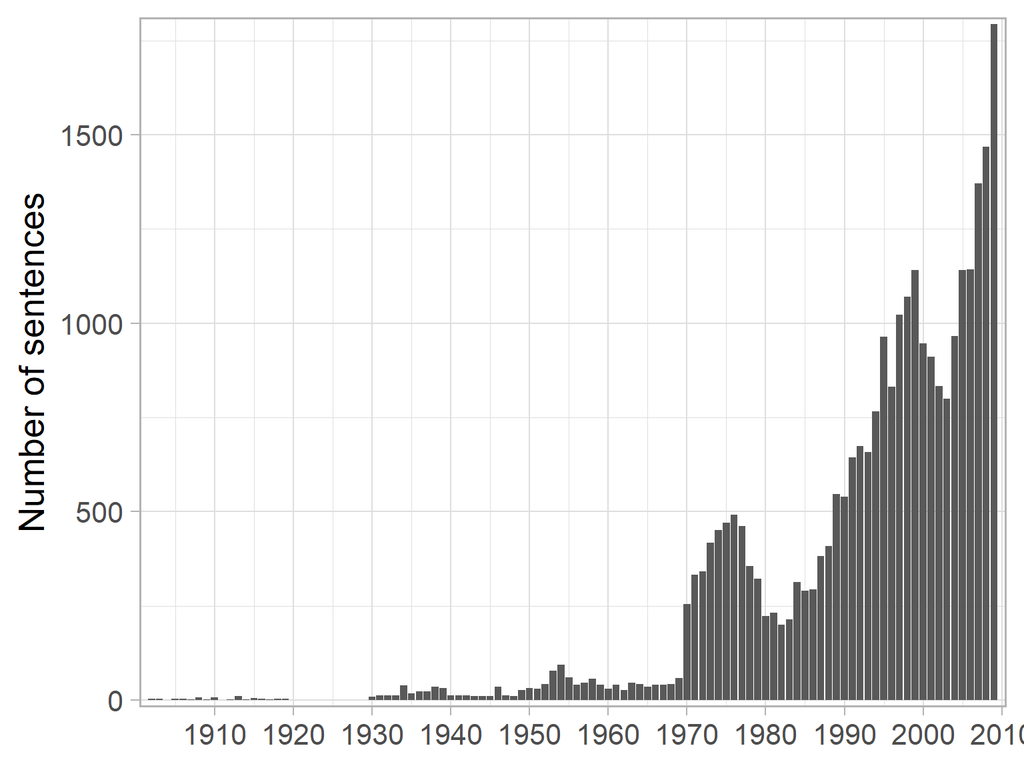

### Closest sentence from ‘rational’ and ‘rationality’ of the backbone community

| Sentence | Title | Year | Journal | Authors | Words Similarity |
| --- | --- | --- | --- | --- | --- |
| Rather, without committing to a specific decision procedure, we merely want to show that a familiar and very simple notion of rationality, based on a single preference relation, imposes restrictions o… | [Non-Deteriorating Choice](https://http://www.jstor.org/stable/40268922) | 2009 | Economica | Walter Bossert, Yves Sprumont | 0.777 |
| With multiple rational preference types, not all ordinally alike, an interior rational expectation dynamic steady-state robustly emerges: It may be impossible to draw any clear inference from history … | [Pathological Outcomes of Observational Learning](https://http://www.jstor.org/stable/2999431) | 2000 | Econometrica | Lones Smith, Peter Sørensen | 0.776 |
| (e.g., ), we argue below that it would be fruitful to extend the analysis to include a salient feature and an implication of bounded rationality in dynamic decision-making that are not captured by the… | [Growth of strategy sets, entropy, and nonstationary bounded recall](https://doi.org/10.1016/j.geb.2008.04.005) | 2009 | Games and Economic Behavior | Neyman A. | 0.770 |
| The rationality hypothesis requires given preferences which are known in advance and regrouped according to the transitivity principle. | [A Critical Review of Strategic Conflict Theory and Socio-political Instability Models](https://http://www.jstor.org/stable/24703028) | 2009 | Revue d’économie politique | Mehrdad Vahabi | 0.769 |
| Our formulation follows the standard economic interpretation of rationality in the sense that choices are based on a single binary relation. | [Weakened WARP and top-cycle choice rules](https://doi.org/10.1016/j.jmateco.2007.05.004) | 2008 | Journal of Mathematical Economics | Ehlers L. | 0.766 |
| Returning to the consumer and the observer from the previous section, and implies that if after having observed the consumer’s choices in K ′· N random examples the observed choices are rationalizable… | Learnability and rationality of choice | 2003 | Journal of Economic Theory | Kalai G. | 0.760 |
| Then there exists a choice function which is optimal-rational with respect to R. We have, thus, realized that rational behavior of individuals follows from very mild conditions imposed upon their pref… | [Rationality without Transitivity](https://http://www.jstor.org/stable/41795073) | 2003 | Journal of Economics | Susanne Fuchs-Seliger, Oliver Mayer | 0.758 |
| Bounded rationality Although the strong rationality assumptions underlying most models serve a useful purpose by providing a benchmark for the analysis of interest group politics, there is mounting em… | [On the Economic Theory of Interest Groups: Towards a Group Frame of Reference in Political Economics](https://http://www.jstor.org/stable/30026077) | 1999 | Public Choice | Frans van Winden | 0.754 |
| The Savage Paradigm A fuller sketch of the Savage paradigm of individual rational decision-making under uncertainty will be given in Section 3, but a few elements are needed here in order to introduce… | [Costly and Bounded Rationality in Individual and Team Decision-making](https://doi.org/10.1093/icc/9.4.623) | 2000 | Industrial and Corporate Change | Radner R. | 0.751 |
| Extensive form rationalizability: Until now, we have been reviewing rationality concepts that are either refinements or weakenings of preference conjecture equilibrium. | [Proper belief revision and equilibrium in dynamic games](https://doi.org/10.1016/j.jet.2006.06.008) | 2007 | Journal of Economic Theory | Perea A. | 0.748 |
| Given inertia in the political process, formation of expectations in a regressive and seemingly myopic fashion may, therefore, be entirely rational. | [Equilibrium Relationships between Money and Other Economic Variables](https://http://www.jstor.org/stable/1821359) | 1985 | The American Economic Review | James R. Lothian | 0.747 |
| Given the use of a logit model, for finite values of the “intensity of choice” parameter, agents are not fully rational in their choice, in the sense that not all use the model that provides the best … | [Heterogeneous expectations, sunspot equilibria and their fragility](https://doi.org/10.1016/j.econlet.2009.08.021) | 2009 | Economics Letters | Berardi M. | 0.747 |
| However, since only the choice behaviour is observable, the probabilistic rationalizability question which has engaged the attention of numerous writers in this line of investigation is analogous to t… | [On probabilistic rationalizability](https://www.jstor.org/stable/10.2307/41107976) | 2009 | Social Choice and Welfare | Shasikanta Nandeibam | 0.745 |
| Manotti The next results show that if J justifies a choice y, it does not need to meet all the standard economic rationality properties even if y is rational in the standard economic sense. | [What Kind of Preference Maximization Does the Weak Axiom of Revealed Preference Characterize?](https://http://www.jstor.org/stable/40282867) | 2008 | Economic Theory | Marco Mariotti | 0.745 |
| By imposing ‘rationality’ conditions on these, the theory of choice is obtained (Deaton and Muellbauer, 1980; Varian, 1992). | Alternative models of individual behaviour and implications for environmental policy | 2000 | Ecological Economics | Van Den Bergh J.C.J.M. | 0.744 |
| We can conclude that there is evidence for an averaging heuristic, and lack of support for alternative bounded rationality hypotheses, such as purely random lapses . | A violation of the monotonicity axiom: Experimental evidence on the conjunction fallacy | 2000 | Journal of Economic Behavior and Organization | Zizzo D.J. | 0.743 |
| With this subjective state space in hand, one expects that an individual who is rational in the usual sense would choose in a way that corresponds to forming subjective probabilities over these states… | [Representing Preferences with a Unique Subjective State Space](https://http://www.jstor.org/stable/2692248) | 2001 | Econometrica | Eddie Dekel, Barton L. Lipman, Aldo Rustichini | 0.737 |
| A revealed preference characterization of dd-rationality is still an open question. | [Consumer Choice and Revealed Bounded Rationality](https://http://www.jstor.org/stable/40283069) | 2009 | Economic Theory | Paola Manzini, Marco Mariotti | 0.735 |
| The concept of rationalizability provides the connection between the observed choice behaviour as represented by a choice system and the hypothesis of stochastic preferences as represented by a probab… | [On probabilistic rationalizability](https://www.jstor.org/stable/10.2307/41107976) | 2009 | Social Choice and Welfare | Shasikanta Nandeibam | 0.734 |
| Branch II: Truly Bounded Rationality Introduction Recall that in the Savage paradigm the DM has a model of the decision problem that is comprised of four building blocks: Rationality in Individual and… | [Costly and Bounded Rationality in Individual and Team Decision-making](https://doi.org/10.1093/icc/9.4.623) | 2000 | Industrial and Corporate Change | Radner R. | 0.734 |

### Closest sentences of the backbone community’s centroid

| Sentence | Title | Year | Journal | Authors | Similarity to Backbone Centroid |
| --- | --- | --- | --- | --- | --- |
| This view of the voting decision appears in classical democratic theory, and has been subjected to empirical tests in various voting studies (where itgenerally does notfare very well).” | [The Political Business Cycle](https://http://www.jstor.org/stable/2296528) | 1975 | The Review of Economic Studies | William D. Nordhaus | 0.872 |
| Anderson, Dillon, and Hardaker (1977) review the attempts to use the axioms of expected utility theory to elicit individual utility functions. | [On-Farm Costs of Reducing Environmental Degradation under Risk](https://www.jstor.org/stable/10.2307/40311344) | 1994 | Estudios Económicos | Parveen P. Setia, David Letson | 0.872 |
| This point may be clarified by considering the view put forward by some utility-theorists that utility is some quality observable by introspection as quantitative, and choice is determined by this qua… | [The Determinateness of the Utility Function](https://http://www.jstor.org/stable/2224802) | 1939 | The Economic Journal | W. E. Armstrong | 0.869 |
| By means of the procedure we have shown that two generalizations of expected utility, introduced independently for different contexts, at closer study in fact are one. | [Under stochastic dominance Choquet-expected utility and anticipated utility are identical](https://doi.org/10.1007/BF00126589) | 1990 | Theory and Decision | Wakker P. | 0.866 |
| The normative appeal and descriptive usefulness of the expected utility hypothesis have been the subject of controversy ever since the work of von Neumann and Morgenstern brought it to the forefront o… | Equilibrium without independence | 1990 | Journal of Economic Theory | Crawford V. | 0.866 |
| ’The author, having so far kept his opinions submerged, is unable to avoid remarking that it would seem “better” to confine utility “theory” to attempts to explain or discern why a person chooses one … | [The Meaning of Utility Measurement](https://http://www.jstor.org/stable/1810289) | 1953 | The American Economic Review | Armen A. Alchian | 0.864 |
| This model assumes rational behavior in the form of expected utility maximization, no income effects, no candidate specific preferences other than the platform choice, positive costs of voting, and kn… | [The Pure Theory of Large Two-Candidate Elections](https://http://www.jstor.org/stable/30023935) | 1984 | Public Choice | John O. Ledyard | 0.864 |
| The approach we take in this paper is different from another common approach to expected utility, the “axiomatic” approach, in at least two aspects. | [The Subjective Expected Utility Hypothesis and Revealed Preference](https://http://www.jstor.org/stable/25054611) | 1991 | Economic Theory | T. Kim | 0.863 |
| However, recent experimental evidence has raised questions concerning the descriptive validity of the axiom and moreover, it has been demonstrated that much of the tractability of the expected utility… | [The Projective Independence Axiom](https://http://www.jstor.org/stable/25054756) | 1994 | Economic Theory | Soo Hong Chew, Larry G. Epstein, Uzi Segal | 0.863 |
| An axiomatic analysis of the present theory and its relation to cumulative utility theory and to expected utility theory are discussed in the appendix; a more comprehensive treatment is presented in W… | [Advances in prospect theory: Cumulative representation of uncertainty](https://doi.org/10.1007/BF00122574) | 1992 | Journal of Risk and Uncertainty | Tversky A. | 0.862 |
| This axiomatization gave rise to a well-known controversy concerning the validity of expected-utility theory in descriptive and in normative respects as well [see, for example, ]. | Present value based portfolio choice | 1994 | Economics Letters | Friis S. | 0.862 |
| There exists an alternative axiomatic generalization of expected utility theory, called rank-dependent or anticipated utility theory, which has been proposed in order to explain Allais-type behavior (… | [Mixture Symmetry and Quadratic Utility](https://http://www.jstor.org/stable/2938244) | 1991 | Econometrica | S. H. Chew, L. G. Epstein, U. Segal | 0.861 |
| The results also establish some new stylized facts for theorists to organize in their efforts to develop alternatives to expected utility theory as a descriptive model of choice under uncertainty. | [Tests of “Fanning Out” of Indifference Curves: Results from Animal and Human Experiments](https://http://www.jstor.org/stable/2006716) | 1990 | The American Economic Review | John H. Kagel, Don N. MacDonald, Raymond C. Battalio | 0.860 |
| An important part of this task is to identify which of the results known to be valid for expected utility theory do or do not hold in models not admitting of a representation of preferences that is “l… | [The value of perfect information in nonlinear utility theory](https://doi.org/10.1007/BF00134120) | 1991 | Theory and Decision | Schlee E. | 0.859 |
| For axiomatic treatments of anticipated utility theory, see , and Segal (1987a). | [The value of information in anticipated utility theory](https://doi.org/10.1007/BF00213262) | 1990 | Journal of Risk and Uncertainty | Schlee E. | 0.858 |
| Contending that this property is a basic feature of any reasonable decision process, he concludes that there is a basic flaw in axiomatic theories justifying expected utility maximization because this… | [Aggregation of Semiorders: Intransitive Indifference Makes a Difference](https://http://www.jstor.org/stable/25054826) | 1995 | Economic Theory | Itzhak Gilboa, Robert Lapson | 0.858 |
| RATIONAL VOTERS’ EQUILIBRIUM We now explore what happens when voters take into account the fact that other voters are also rational. | [The Pure Theory of Large Two-Candidate Elections](https://http://www.jstor.org/stable/30023935) | 1984 | Public Choice | John O. Ledyard | 0.858 |
| Introduction According to the theory of the rational voter’s behavior (Riker and Ordeshook, 1968), the decision to vote depends, among other things, on the expected effectiveness of his vote to bring … | [Is Political Rivalry an Incentive to Vote?](https://http://www.jstor.org/stable/30026527) | 1988 | Public Choice | Henri Capron, Jean-Louis Kruseman | 0.858 |

### Closest sentences of each HDBSCAN cluster’s centroid composing the backbone community

| Sentence | Title | Year | Journal | Authors | Similarity to HDSBSCAN Centroid |
| --- | --- | --- | --- | --- | --- |
| As over against such a doctrine the conception of marginal utility, as the key to the relation between prices and wants, embodies a vital and important truth. | [Economic Theory in an Era of Social Readjustment](https://http://www.jstor.org/stable/1814006) | 1919 | The American Economic Review | J. M. Clark | 0.822 |
| If the distinction between desires for present and desires for future gratification be neglected, it may be said that commodities of equal value have about the same marginal utility or capacity to sat… | [The Taxation of Luxuries and the Rate of Interest](https://http://www.jstor.org/stable/1884736) | 1919 | The Quarterly Journal of Economics | A. F. McGoun | 0.796 |
| deed, escape the necessity of finding a common denominator of “utility,” but it does so only by becoming inconsequential. | [The Futility of Marginal Utility](https://http://www.jstor.org/stable/1820794) | 1910 | Journal of Political Economy | E. H. Downey | 0.792 |
| “What becomes of our reasoning as to marginal utility?” | [Seligman’s Principles of Economics: A Reply and a Rejoinder](https://http://www.jstor.org/stable/1883753) | 1906 | The Quarterly Journal of Economics | F. W. Taussig | 0.789 |
| Then there is the fact that the study of utility seems to be oriented by the question: “To what is value equal?” | [Economic Theory in an Era of Social Readjustment](https://http://www.jstor.org/stable/1814006) | 1919 | The American Economic Review | J. M. Clark | 0.784 |
| fying hunger, and we obtain the concept of utility that has fathered the above criticisms and inveigled economics into the hopeless search for a unit of sensation. | [Index Numbers and the Standard of Value](https://http://www.jstor.org/stable/1820711) | 1902 | Journal of Political Economy | T. S. Adams | 0.780 |
| things being equal, afford increments of utility, the magnitude of each of which is independent of the total quantity of the comminodity that the individual may choose to take. | [Some Remarks on Utility](https://http://www.jstor.org/stable/2956866) | 1903 | The Economic Journal | A. C. Pigou | 0.773 |
| 2 To the writer this statement of the case seems superficial, in that it overlooks the elementary facts that the essence of production is utility creation and that in consumption men tend to equalize … | [Rent and Price: “Alternative Use” and “Scarcity Value”](https://http://www.jstor.org/stable/1885827) | 1910 | The Quarterly Journal of Economics | Lewis H. Haney | 0.772 |
| utility may have some tenldency to establish the end proposed by utilitarianism, and considerable efficacy in supplying means thereto. | [Appreciations of Mathematical Theories](https://http://www.jstor.org/stable/2220666) | 1907 | The Economic Journal | F. Y. Edgeworth | 0.771 |
| This crude reductio ad absurdum may serve to make the reader doubt whether the principle of equal proportional sacrifice of utility can be sound. | [The Utility of Income and Progressive Taxation](https://http://www.jstor.org/stable/2222207) | 1913 | The Economic Journal | S. J. Chapman | 0.771 |

| Sentence | Title | Year | Journal | Authors | Similarity to HDSBSCAN Centroid |
| --- | --- | --- | --- | --- | --- |
| This point may be clarified by considering the view put forward by some utility-theorists that utility is some quality observable by introspection as quantitative, and choice is determined by this qua… | [The Determinateness of the Utility Function](https://http://www.jstor.org/stable/2224802) | 1939 | The Economic Journal | W. E. Armstrong | 0.869 |
| I,t can now be maintained, in conclusion, that the question of the measur-ability of utility is mainly one of methodological interest. | [A Note on the Determinateness of the Utility Function](https://http://www.jstor.org/stable/2967563) | 1935 | The Review of Economic Studies | R. G. D. Allen | 0.845 |
| While the view that utility is want-intensity is a possible view, the question of the determinateness of the utility function is not bound up with our adoption of such a view. | [The Determinateness of the Utility Function](https://http://www.jstor.org/stable/2224802) | 1939 | The Economic Journal | W. E. Armstrong | 0.834 |
| One answer to this question points to the much debated problem of the measurability of utility. | [Composite Commodities and the Problem of Index Numbers](https://http://www.jstor.org/stable/1907120) | 1936 | Econometrica | Wassily Leontief | 0.828 |
| But even in the narrow range of the Theory of Utility, the specific subjective psychological foundation of that theory will be ruled out, for in replacing the Theorem of Decreasing Marginal Utility, b… | [II](https://http://www.jstor.org/stable/2967553) | 1934 | The Review of Economic Studies | Harro Bernardelli | 0.827 |
| Without discussing the controversial issue whether or not utility can be considered as a measurable magnitude (the opponents of this assumption seem still to have a better case), we may accept for a m… | [Composite Commodities and the Problem of Index Numbers](https://http://www.jstor.org/stable/1907120) | 1936 | Econometrica | Wassily Leontief | 0.823 |
| Two courses have been followed by modern writers who have developed creditable arguments for the validity of the principle of diminishing marginal utility: first, “desired- ness” has been substituted … | [Recent and Contemporary Theories of Progressive Taxation](https://http://www.jstor.org/stable/1824777) | 1938 | Journal of Political Economy | Elmer D. Fagan | 0.822 |
| It is not necessary to make any assumption about the existence of ” total utility” or about the measurability of ” utility”; the hedonistic hypothesis has been rendered superfluous. | [The Foundations of a Mathematical Theory of Exchange](https://http://www.jstor.org/stable/2549268) | 1932 | Economica | R. G. D. Allen | 0.814 |
| It must, however, be insisted that this does not imply that utility is an additive quality like extensity or temporality, or the numerability of mere collections of objects such as a number of atoms. | [The Determinateness of the Utility Function](https://http://www.jstor.org/stable/2224802) | 1939 | The Economic Journal | W. E. Armstrong | 0.809 |
| Even if it be granted that utility is some introspected quality such as want-intensity, the objection cannot be sustained provided, of course, we do not mean by quantitative something that by definiti… | [The Determinateness of the Utility Function](https://http://www.jstor.org/stable/2224802) | 1939 | The Economic Journal | W. E. Armstrong | 0.807 |

| Sentence | Title | Year | Journal | Authors | Similarity to HDSBSCAN Centroid |
| --- | --- | --- | --- | --- | --- |
| It still remains to be demonstrated what more could be done with “absolute” utility; and if one would apply the concept of cardinal utility to problems of social welfare, a “sound scientific theory” o… | [Professor Knight and the Theory of Demand](https://http://www.jstor.org/stable/1825792) | 1946 | Journal of Political Economy | Robert L. Bishop | 0.815 |
| Every valuation is a comparison; we have no conception of an absolute utility or an absolute 21 As mentioned above (p. I4I), when a consumer’s tastes are consistent with the assumption of independent … | [Professor Knight and the Theory of Demand](https://http://www.jstor.org/stable/1825792) | 1946 | Journal of Political Economy | Robert L. Bishop | 0.810 |
| Before taking the road at the logical endpoint of which lies Samuelson’s consistency postulate or, as some might put it, the proof that utility is both an inadmissible and a redundant construct, Fishe… | [Irving Fisher’s Econometrics](https://http://www.jstor.org/stable/1907276) | 1948 | Econometrica | Joseph A. Schumpeter | 0.796 |
| The main emphasis in the whole subsequent analysis is on the ordinal measurability of the s. We also imply that the partial and total individual utilities which are ultimate components of the s assume… | [ECONOMIC STRUCTURE AND PLANNING](https://http://www.jstor.org/stable/40747258) | 1948 | Zeitschrift für die gesamte Staatswissenschaft / Journal of Institutional and Theoretical Economics | THEO SURÁNYI-UNGER | 0.783 |
| This implies only ordering, not measurement, of each individual’s utility. | [The Foundations of Welfare Economics](https://http://www.jstor.org/stable/1905465) | 1942 | Econometrica | Oscar Lange | 0.781 |
| The utility of a good itself, according to this view, is a mathematical abstraction, derivable in a theory of consumption under the condition that the final utilities of the several alternative uses o… | [Some Fundamentals in Liquidity Theory](https://http://www.jstor.org/stable/1884572) | 1945 | The Quarterly Journal of Economics | M. Bronfenbrenner | 0.779 |
| Since exact utility measurement by direct introspection has been generally rejected, and deservedly so, a universally dependent utility must continue to defy attempts at cardinal measurement.9 We may … | [Consumer’s Surplus and Cardinal Utility](https://http://www.jstor.org/stable/1881755) | 1943 | The Quarterly Journal of Economics | Robert L. Bishop | 0.778 |
| “63 One cannot disagree with this statement any more than with the statement that the price of butter measures the marginal utility of butter to each member of the community.64 Both statements are eit… | [Liquidity Preference and the Theory of Interest and Money](https://http://www.jstor.org/stable/1905567) | 1944 | Econometrica | Franco Modigliani | 0.778 |
| It is not necessary for our purpose to be able to measure utility or welfare, for we insist merely that the index whereby we measure utility increases when the individual in question feels himself bet… | [The Community Indifference Map: A Construction](https://http://www.jstor.org/stable/2296278) | 1949 | The Review of Economic Studies | William J. Baumol | 0.776 |
| Must not real utility or incidence be brought into the picture? | [National Product Distortions: War and Postwar](https://http://www.jstor.org/stable/1052759) | 1945 | Southern Economic Journal | Joseph Mayer | 0.775 |

Sentence

Title

Year

Journal

Authors

Similarity to HDSBSCAN Centroid

’The author, having so far kept his opinions submerged, is unable to avoid remarking that it would seem “better” to confine utility “theory” to attempts to explain or discern why a person chooses one thing rather than another-at equal pric

[The Meaning of Utility Measurement](https://http://www.jstor.org/stable/1810289)

1953

The American Economic Review

Armen A. Alchian

0.864

We may assume for the moment in the following that the utility for different individuals could be compared and that utility can be cardinally measured.

[Some Problems of Income Determination and Welfare](https://http://www.jstor.org/stable/41796010)

1959

Zeitschrift für Nationalökonomie / Journal of Economics

Walter Froehlich

0.854

Utility is “measurable” for one purpose but not for the other.9 s Some problems involved in this assumption and in its relaxation are discussed by N. Geogescu-Roegen, “The Theory of Choice and the Constancy of Economic Laws,” Quart.

[The Meaning of Utility Measurement](https://http://www.jstor.org/stable/1810289)

1953

The American Economic Review

Armen A. Alchian

0.846

The problem is more basic than merely having or not having a cardinal measure of utility.

[A Probabilistic Theory of Consumer Behavior](https://http://www.jstor.org/stable/1881863)

1956

The Quarterly Journal of Economics

Richard E. Quandt

0.842

Utility is used as if its meaning were self-evident and did not depend on the context in which and the purpose for which it is used, itself, I believe, a reflection of a failure to recognise that a concept used in the interpretation of observable phenomena has no meaning independently of the operations specified for measuring it.

[What All is Utility?](https://http://www.jstor.org/stable/2227317)

1955

The Economic Journal

Milton Friedman

0.840

Taking utility in the sense of “desiredness,” the measurement of utility can be achieved only if some restrictive assumptions can be made regarding the preferences, as manifested by the behavior, of individuals acting on the market, just as measurement of welfare is only possible if some restrictive assumptions can be made regarding ethical judgments.

[A Cardinal Concept of Welfare](https://http://www.jstor.org/stable/1885309)

1952

The Quarterly Journal of Economics

Marcus Fleming

0.836

We have seen that the measurement of utility is a matter of no theoretical importance and that an undue emphasis on numbers carries with it certain dangers, since it tends to distract attention from the more important question whether utilities can or cannot be added and subtracted.

[Concerning Utility](https://http://www.jstor.org/stable/2601492)

1954

Economica

Charles Kennedy

0.835

If, in Humpty Dumpty’s words, I ” choose ” utility ” to mean ” that property of a person’s position in life which is measured by the product of the number of hairs on his head and the number of books on his shelves, then utility is measurable by a scale that is unique with respect even to origin and unit of measure.

[What All is Utility?](https://http://www.jstor.org/stable/2227317)

1955

The Economic Journal

Milton Friedman

0.831

3. The traditional theory does not state how utility is to be measured; here it is true only with respect to a particular method of measurement, which is only one of several available.

[Convex Indifference Curves and Diminishing Marginal Utility](https://http://www.jstor.org/stable/1824832)

1957

Journal of Political Economy

W. M. Gorman

0.829

The measurability and comparability of utility, 5.

[A Revolutionist’s Handbook](https://http://www.jstor.org/stable/1881957)

1950

The Quarterly Journal of Economics

D. H. Robertson

0.828

Sentence

Title

Year

Journal

Authors

Similarity to HDSBSCAN Centroid

Evidently, those who believe in preferential sets have extended the meaning of the term preference so as to include not only preference, in the above sense, but a relation between alternatives that is supposed to exist though incapable of being observed.

[Utility and the “Ordinalist Fallacy”](https://http://www.jstor.org/stable/2295985)

1958

The Review of Economic Studies

W. E. Armstrong

0.843

Various strength of preference situations can be assumed.

[On Consumer Grades for Foods](https://http://www.jstor.org/stable/1234489)

1956

Journal of Farm Economics

V. James Rhodes, Elmer R. Kiehl

0.839

It becomes necessary to reconsider the concept of preference.

[A Probabilistic Theory of Consumer Behavior](https://http://www.jstor.org/stable/1881863)

1956

The Quarterly Journal of Economics

Richard E. Quandt

0.831

They suggest that preferences and indifferences are to be found not between alternatives but between the probabilities (including certainty) of alternatives.

[Utility and the “Ordinalist Fallacy”](https://http://www.jstor.org/stable/2295985)

1958

The Review of Economic Studies

W. E. Armstrong

0.829

We must, therefore, assume for alternatives consisting of two or more commodities that the relation of preference does not always hold between alternatives, and therefore that choice does not necessarily reveal preference.

[A Note on the Theory of Consumer’s Behaviour](https://http://www.jstor.org/stable/2661751)

1950

Oxford Economic Papers

W. E. Armstrong

0.818

It does, however, suggest that where choice depends on conflicting criteria, preference patterns may be intransitive unless one criterion dominates.

[Intransitivity, Utility, and the Aggregation of Preference Patterns](https://http://www.jstor.org/stable/1909827)

1954

Econometrica

Kenneth O. May

0.814

2 The cited works of Houthakker, Little, and myself show that revealed preference theory in its narrow sense can identify regular situations that are indifferent only by an infinite sequence of comparison points.

[Consumption Theorems in Terms of Overcompensation Rather Than Indifference Comparisons](https://http://www.jstor.org/stable/2550984)

1953

Economica

Paul A. Samuelson

0.814

2. There is a tendency for individuals to deduce preferences so as to produce firstorder preferential sets that maintain the transitiveness of preference, whether direct or deduced.

[Utility and the “Ordinalist Fallacy”](https://http://www.jstor.org/stable/2295985)

1958

The Review of Economic Studies

W. E. Armstrong

0.813

I also made the suggestion in this article (p. 457, footnote 2) that the preference theorist with a behaviourist bent might escape the difficulties inherent in the subjective concept of indifference by dropping the latter altogether and defining preference as choice.

[A Note on the Theory of Consumer’s Behaviour](https://http://www.jstor.org/stable/2661751)

1950

Oxford Economic Papers

W. E. Armstrong

0.812

He has shown that if a choice is to be made from among more than two alternatives, we cannot, in general, construct a social welfare function that could be regarded as a true representation of individual preferences and would at the same time lead to a consistent and non-contradictory social ordering of all available alternatives.

[The State of Welfare Economics](https://http://www.jstor.org/stable/1802104)

1951

The American Economic Review

Tibor Scitovsky

0.811

| Sentence | Title | Year | Journal | Authors | Similarity to HDSBSCAN Centroid |
| --- | --- | --- | --- | --- | --- |
| I refer, of course, to the theory of utility. | [Artistic Goals, Scientific Method and Economics](https://http://www.jstor.org/stable/1055641) | 1967 | Southern Economic Journal | Ralph W. Pfouts | 0.827 |
| We have not claimed any precise knowledge of individuals’ utility functions but have concluded that utility must be a function of many desired items, that there are trade-off or substitution possibili… | [Divergences between Individual and Total Costs within Government](https://http://www.jstor.org/stable/1818510) | 1964 | The American Economic Review | Roland N. McKean | 0.821 |
| The reader should note that the assumption that utility depends only on | [The Consumer’s Demand for Money: A Neoclassical Approach](https://http://www.jstor.org/stable/1829969) | 1969 | Journal of Political Economy | Brian Motley | 0.817 |
| By making the (unwarranted) leap to the assumption of cardinal utility, an alternative interpretation can be given. | [The Interest Rate, Taxation, and the Personal Savings Incentive](https://http://www.jstor.org/stable/1879515) | 1968 | The Quarterly Journal of Economics | M. S. Feldstein, S. C. Tsiang | 0.811 |
| If his statement is strictly interpreted-so that we have only the definitions but no reasons for them-then no value judgments are revealed to us; whenever we have the choice between any two points U a… | [Are Formal Welfare Criteria Required?](https://http://www.jstor.org/stable/2228296) | 1964 | The Economic Journal | S. K. Nath | 0.800 |
| Briefly, it seems to me that our present concept of a utility function has long been outmoded. | [Permanent Income and Transitory Balances: Hahn’s Paradox](https://http://www.jstor.org/stable/2661782) | 1963 | Oxford Economic Papers | Robert W. Clower | 0.799 |
| porate into individual utility functions some-but not all-of the substance of the kinds of value judgments about distribution for which we have argued in this paper. | [How Income Ought to be Distributed: Paradox Lost](https://http://www.jstor.org/stable/1828722) | 1961 | Journal of Political Economy | Franklin M. Fisher, Jerome Rothenberg | 0.796 |
| Without invoking so restrictive an example it should be clear that what is at issue is the large loss of utility by A with no commensurable gain by B in the pursuit of equality of total utility, an is… | [The Recent Debate on Welfare Criteria](https://http://www.jstor.org/stable/2662382) | 1965 | Oxford Economic Papers | E. J. Mishan | 0.783 |
| But it appears to be generally accepted that when later utilitarians, like Marshall, thought about utility they viewed it as a magnitude that can be measured uniquely up to a proportional transformati… | [On the Concept of Optimum Population](https://http://www.jstor.org/stable/2296429) | 1969 | The Review of Economic Studies | P. S. Dasgupta | 0.779 |
| Since the tendency to value-oriented interpretation of some scientific terms has been demonstrated by G. Myrdal, and thus to a certain extent has been rendered harmless, another objection has been rai… | [Some Reflections on the Relation between Economic Theory and Empirical Reality](https://http://www.jstor.org/stable/3439181) | 1967 | The Swedish Journal of Economics | Tõnu Puu | 0.779 |

| Sentence | Title | Year | Journal | Authors | Similarity to HDSBSCAN Centroid |
| --- | --- | --- | --- | --- | --- |
| To cover such possibilities, the theory of utility has been generalized by either weakening or omitting the Archimedean assumption [5, 21, 32]. | [Stochastic Programming, Utility, and Sequential Decision Problems in Farm Management](https://http://www.jstor.org/stable/1238222) | 1971 | American Journal of Agricultural Economics | Allan N. Rae | 0.857 |
| This général formulation23) implies the possibility of choosing between différent Utility functions U (B). | [Bernoulli’s Utility Theory and Historical Ramifications](https://http://www.jstor.org/stable/23805838) | 1972 | Jahrbücher für Nationalökonomie und Statistik / Journal of Economics and Statistics | Hans-Werner Gottinger | 0.846 |
| It is this property that makes the expected utility model attractive for normative purposes in difficult decision problems when the decision maker’s preferences are not fully developed in a consistent… | [Acceptability of Three Normative Methods in Insurance Decision Making](https://www.jstor.org/stable/10.2307/251402) | 1971 | The Journal of Risk and Insurance | C. Arthur Williams, Jr., John Neter | 0.827 |
| Moreover, it is judged not on predictive merit but by its consistency with the existence of properly postulated utility functions [Richter, 41]. | [Explanation and Value in Economics](https://http://www.jstor.org/stable/4224885) | 1979 | Journal of Economic Issues | Timothy J. Brennan | 0.822 |
| Secondly, we argue that the probabilities used in forming an expected utility must be construed as subjective probabilities in order to have any meaning. | [A Homiletic Exposition of the Expected Utility Hypothesis](https://http://www.jstor.org/stable/2553568) | 1977 | Economica | Charles Blackorby, Russell Davidson, David Donaldson | 0.820 |
| The combination of these two assumptions, both popular and neither very improbable, has been shown by Hicks [6] to specify the utility function completely except for certain parameters. | [Fiscal Policy and Private Saving: A Utility Analysis](https://http://www.jstor.org/stable/2525342) | 1970 | International Economic Review | Ashok Guha | 0.818 |
| (Only recently there has been some interest in conditional (expected) utility (see [1]), however, with different assumptions, methods and goals as those presented here). | [Conditional Utility](https://http://www.jstor.org/stable/41797540) | 1973 | Zeitschrift für Nationalökonomie / Journal of Economics | Hans-Werner Gottinger | 0.818 |
| To get around this problem, a strong assumption on the utility function, the “additive” or “separable” utility was introduced.’ | [An Intertemporal Analysis of the Nature of Demand for Food Products](https://http://www.jstor.org/stable/1237389) | 1970 | American Journal of Agricultural Economics | Floyd K. Harmston, Hiroyuki Hino | 0.816 |
| The latter have shown that, provided an individual’s preference ordering over alternative (conditional) 6 decisions obeys a restricted set of fairly plausible axioms, then under the circumstances desc… | [The Value of Changes in the Probability of Death or Injury](https://http://www.jstor.org/stable/1837150) | 1974 | Journal of Political Economy | Michael Jones-Lee | 0.816 |
| In the first place we try as far as possible to derive propositions based on general utility functions, although where appropriate, we use special cases to illustrate particular propositions. | [Technological and Price Uncertainty in a Ricardian Model of International Trade](https://http://www.jstor.org/stable/2296713) | 1974 | The Review of Economic Studies | Stephen J. Turnovsky | 0.815 |

| Sentence | Title | Year | Journal | Authors | Similarity to HDSBSCAN Centroid |
| --- | --- | --- | --- | --- | --- |
| This view of the voting decision appears in classical democratic theory, and has been subjected to empirical tests in various voting studies (where itgenerally does notfare very well).” | [The Political Business Cycle](https://http://www.jstor.org/stable/2296528) | 1975 | The Review of Economic Studies | William D. Nordhaus | 0.872 |
| Consider what we term a narrow economic model of the voting decision, i.e., one which not only makes use of the logical or economic approach to the voter’s decision calculus, but also limits the argum… | [Some Simple Economics of Voting and Not Voting](https://http://www.jstor.org/stable/30022736) | 1973 | Public Choice | R. D. Tollison, T. D. Willett | 0.849 |
| “A Theory of the Calculus of Voting,” Am. | [A Note on the Probability of a Tied Election](https://http://www.jstor.org/stable/30022829) | 1975 | Public Choice | Nathaniel Beck | 0.847 |
| Many interesting questions thus arise concerning the conditions under which strategic voting would become a rational choice on the part of the voter(s). | Sophisticated voting with information for two voting functions | 1977 | Journal of Economic Theory | Adelsman R. | 0.844 |
| When this uncertainty is absent such that the direction and ranking of other voters’ preferences are known, strategic behavior can be adopted making the final outcome dependent upon the relative inten… | Criteria for jurisdictional design. Issues in defining the scope and structure of river basin authorities and other public decision-making bodies | 1976 | Journal of Environmental Economics and Management | McMillan M. | 0.843 |
| As a prelude to a more structured investigation of the electoral process, the implications of a quite restrictive set of assumptions about the behavior of utility maximizing voters will be developed i… | [Spending for Education: The Exercise of Public Choice](https://http://www.jstor.org/stable/1924240) | 1978 | The Review of Economics and Statistics | Michael C. Lovell | 0.837 |
| The point of view taken here differs from that of other work in this area (e.g., [1, 2, 3, 4]) chiefly in asking that the procedure work for all possible sizes of the voting population, rather than fo… | [Aggregation of Preferences with Variable Electorate](https://http://www.jstor.org/stable/1914033) | 1973 | Econometrica | John H. Smith | 0.833 |
| Throughout the paper we have assumed that all voters follow the same strategy, i.e., they all either employ simple majority rule, or naive expectations, or sophisticated expectations. | [The Social Gains from Exchanging Votes: A Simulation Approach](https://http://www.jstor.org/stable/30022683) | 1972 | Public Choice | Dennis C. Mueller, Geoffrey C. Philpotts, Jaroslav Vanek | 0.833 |
| Although the emphasis is now on the suitability of a given strategy, the result bears importantly on the equilibrium or stability of voting situations. | [On a Difficulty in the Analysis of Strategic Voting](https://http://www.jstor.org/stable/1913904) | 1978 | Econometrica | Manimay Sengupta | 0.832 |
| If a voter has strong preferences, only one of his voting strategies is in every way consistent with “sincere” voting; call this his sincere voting strategy, the n-tuple of such strategies the sincere… | [Logrolling, Vote Trading, and the Paradox of Voting: A Game-Theoretical Overview](https://http://www.jstor.org/stable/30022966) | 1977 | Public Choice | Nicholas R. Miller | 0.831 |

| Sentence | Title | Year | Journal | Authors | Similarity to HDSBSCAN Centroid |
| --- | --- | --- | --- | --- | --- |
| The desirability of choices made is evaluated in terms of preferences each individual is assumed to have among the alternatives. | [Construction of Outcome Functions Guaranteeing Existence and Pareto Optimality of Nash Equilibria](https://http://www.jstor.org/stable/1913838) | 1978 | Econometrica | Leonid Hurwicz, David Schmeidler | 0.840 |
| That a primitive concept like the coincidence of different interpretations of revealed preference can be taken to be a complete criterion of rationality of choice is of some interest in understanding … | [Choice Functions and Revealed Preference](https://http://www.jstor.org/stable/2296384) | 1971 | The Review of Economic Studies | Amartya K. Sen | 0.840 |
| Suppose the individual’s choice behavior obeys Axioms 2.1, 2.2, 2.3, and 3.1 and, as guaranteed by Theorem 1, his choice behavior is represented by functions U and u,. | [Temporal Resolution of Uncertainty and Dynamic Choice Theory](https://http://www.jstor.org/stable/1913656) | 1978 | Econometrica | David M. Kreps, Evan L. Porteus | 0.835 |
| I. RATIONALITY AND REVEALED PREFERENCE For the sake of logical clarity, we discuss in this section the concept of rationality and that of revealed preference in abstraction from the problem of collect… | [Remarks on the Theory of Collective Choice](https://http://www.jstor.org/stable/2553273) | 1976 | Economica | Kotaro Suzumura | 0.814 |
| Some sets of preferences of individuals serve only to narrow the field of choice but not to uniquely determine the final outcome. | [Strategy-Proofness and Social Choice Functions without Singlevaluedness](https://http://www.jstor.org/stable/1911220) | 1977 | Econometrica | Jerry S. Kelly | 0.812 |
| The underlying idea is that certain preference considerations are more duly allowed for in some kinds of decisions than in others. | Implicit social preferences in the Norwegian system of indirect taxation | 1978 | Journal of Public Economics | Christiansen V. | 0.808 |
| The main point of our paper is that the theory of choice, as formulated, does not make adequate use of its relatively powerful implications. | [On the New Theory of Consumer Behavior](https://http://www.jstor.org/stable/3439147) | 1973 | The Swedish Journal of Economics | Robert T. Michael, Gary S. Becker | 0.807 |
| Given the set of alternatives available for society to choose among, it could be expected that, ideally, one could observe all preferences among the available alternatives, but there would be no way t… | [The Possibility of Rational Social Choice in an Economy](https://http://www.jstor.org/stable/1832208) | 1979 | Journal of Political Economy | Martin J. Bailey | 0.805 |
| Under varying sets of assumed preferences, different results would emerge. | [Utility Interdependence and Redistribution: Methodological Implications for Welfare Economics and the Theory of the Public Household](https://doi.org/10.1177/109114217500300301) | 1975 | Public Finance Review | Johnston J.F. | 0.804 |
| In this section we shall apply the theorems of Sections 2 and 4 to several general formulations of revealed preference. | Separation theorems and expected utilities | 1975 | Journal of Economic Theory | Fishburn P. | 0.803 |

Sentence

Title

Year

Journal

Authors

Similarity to HDSBSCAN Centroid

5. For other familiar reasons one may question the appropriateness of using von Neumann-Morgenstern expected utility theory (Machina, 1987).

[Randomization with Asymmetric Information](https://http://www.jstor.org/stable/2555661)

1988

The RAND Journal of Economics

Richard Arnott, Joseph E. Stiglitz

0.850

An alternative generalization of expected utility theory, called anticipated utility, was suggested by Quiggin [7] (see also [10] and [8]).

[Probabilistic Insurance and Anticipated Utility](https://www.jstor.org/stable/10.2307/253329)

1988

The Journal of Risk and Insurance

Uzi Segal

0.848

In the next section of this paper, we will offer an example in which a reasonable decision maker might find some of the standard axioms of utility theory less appealing.

[Risk Conservatism and the Circumstances of Utility Theory](https://http://www.jstor.org/stable/1240411)

1983

American Journal of Agricultural Economics

Talbot Page, Douglas MacLean

0.847

1. Nonexpected Utility Underlying Preferences In light of the growing empirical evidence that individuals’ underlying preferences do not satisfy the independence axiom of expected utility theory (see Section 5 for references), it is useful to consider how the above analysis extends to the case of nonexpected utility underlying preferences.

Temporal risk and the nature of induced preferences

1984

Journal of Economic Theory

Machina M.

0.846

We wish to discover the essential property of expected utility that entails this type of consistency between ex post and ex ante preferences.

Consistent choice under uncertainty

1985

Journal of Mathematical Economics

Clark S.A.

0.846

147-49, and the references cited therein), merely that it is a different issue from that of separable versus nonseparable (i.e., expected utility versus non-expected utility) preferences over well-defined probability distributions, which forms the topic of this paper.

[Dynamic Consistency and Non-Expected Utility Models of Choice Under Uncertainty](https://http://www.jstor.org/stable/2727025)

1989

Journal of Economic Literature

Mark J. Machina

0.845

One special example of this case has been considered by Shapiro and Miyao [1978], where all individuals will obtain a certain (common) utility level from each alternative after their choice is made, i.e., (68) u(Nj) = ui(Ni), i = -,…, n; k = 1,…, n, but individuals have different prior expectations about utility from each alternative before their choice is made.

[Discrete Choice and Variable Returns to Scale](https://http://www.jstor.org/stable/2526276)

1981

International Economic Review

Takahiro Miyao, Perry Shapiro

0.843

In the wake of the new evidence, an array of representations of preferences has been proposed to accommodate failures of one or more of the traditional axioms.2 Although some new models are solely descriptive (Kahneman and Tversky, 1979), others have normative interest as competitors of the von Neumann-Morgenstern expected utility theory (Quiggin, I982; Machina, I982; Chew, I982, I983; Fishburn, I982) or of Savage’s subjective-probability expected utility theory (Bell I982; Loomes and Sugden, I982, I987; Schmeidler, I984; Gilboa, I985; Luce and Narens, I985; Fishburn, I984 b, i986b).

[Reconsiderations in the Foundations of Decision Under Uncertainty](https://http://www.jstor.org/stable/2233074)

1987

The Economic Journal

Peter C. Fishburn

0.841

However, we can exploit another result from standard calculus to show how “expected utility” results may be applied to the exact global analysis of non-expected utility preferences.

[Choice Under Uncertainty: Problems Solved and Unsolved](https://http://www.jstor.org/stable/1942952)

1987

The Journal of Economic Perspectives

Mark J. Machina

0.839

This special case of our theory corresponds with expected utility theory in its traditional or Bernoullian formn, in which utility is interpreted as a psychological experience.

[Regret Theory: An Alternative Theory of Rational Choice Under Uncertainty](https://http://www.jstor.org/stable/2232669)

1982

The Economic Journal

Graham Loomes, Robert Sugden

0.839

| Sentence | Title | Year | Journal | Authors | Similarity to HDSBSCAN Centroid |
| --- | --- | --- | --- | --- | --- |
| This model assumes rational behavior in the form of expected utility maximization, no income effects, no candidate specific preferences other than the platform choice, positive costs of voting, and kn… | [The Pure Theory of Large Two-Candidate Elections](https://http://www.jstor.org/stable/30023935) | 1984 | Public Choice | John O. Ledyard | 0.864 |
| RATIONAL VOTERS’ EQUILIBRIUM We now explore what happens when voters take into account the fact that other voters are also rational. | [The Pure Theory of Large Two-Candidate Elections](https://http://www.jstor.org/stable/30023935) | 1984 | Public Choice | John O. Ledyard | 0.858 |
| Introduction According to the theory of the rational voter’s behavior (Riker and Ordeshook, 1968), the decision to vote depends, among other things, on the expected effectiveness of his vote to bring … | [Is Political Rivalry an Incentive to Vote?](https://http://www.jstor.org/stable/30026527) | 1988 | Public Choice | Henri Capron, Jean-Louis Kruseman | 0.858 |
| Much of the preceding discussion is designed to suggest that this rationalistic expectation about voter decision-making is | [Comments on the Denzau and Maser Papers](https://http://www.jstor.org/stable/30024842) | 1985 | Public Choice | Elmer E. Cornwell | 0.853 |
| And it is worth noting here that Greenberg and Weber [1985, p 698] informally defend an assumption of sincere voting in their model by arguing that if the legislative outcome function were given by ma… | [Sincere Voting in Models of Legislative Elections](https://www.jstor.org/stable/10.2307/41105923) | 1989 | Social Choice and Welfare | D. Austen-Smith | 0.850 |
| There appear to be two main stumbling blocks to a consistent theory based on the rational behavior of participants: (1) the theoretical proposition that, given any realistic assumption about the cost … | [The Pure Theory of Large Two-Candidate Elections](https://http://www.jstor.org/stable/30023935) | 1984 | Public Choice | John O. Ledyard | 0.847 |
| Introduction If he is rational, a citizen will vote only if his expected gain from voting (namely, the probability that his vote will make a difference in electing his preferred candidate, multiplied … | [To Vote or Not to Vote: The Paradox of Nonvoting](https://http://www.jstor.org/stable/30023745) | 1984 | Public Choice | Guillermo Owen, Bernard Grofman | 0.842 |
| (Assuming majority rule, no ties, and separability of voters’ preferences [three assumptions satisfied by Example B], Oppenheimer [1972] and Koehler [1975] argued that [rational] vote trading preclude… | [The Universal-Instability Theorem](https://http://www.jstor.org/stable/30023509) | 1981 | Public Choice | Thomas Schwartz | 0.839 |
| We summarize the implications of the two theories of voting behavior in Table 1. | [When Votes Are Words Not Deeds: Some Evidence from the Nuclear Freeze Referendum](https://http://www.jstor.org/stable/30024929) | 1988 | Public Choice | Susan Feigenbaum, Lynn Karoly, David Levy | 0.837 |
| VOTING AND INFLUENCE Theories of rational politics usually build on the given political preferences of voters, be they theories of the median voter [Romer and | [A Theory of Competition Among Pressure Groups for Political Influence](https://http://www.jstor.org/stable/1886017) | 1983 | The Quarterly Journal of Economics | Gary S. Becker | 0.835 |

| Sentence | Title | Year | Journal | Authors | Similarity to HDSBSCAN Centroid |
| --- | --- | --- | --- | --- | --- |
| Whenever power is divided among many elected officials, a theory of rational voting must take account, not only of the probability of helping one candidate to win rather than another, but also the pro… | Theoretical comparisons of electoral systems | 1999 | European Economic Review | Myerson R.B. | 0.847 |
| D This conclusion, asserting that for even values of n just continuity severely limits the impact of almost all voters, extends to all n > 1 values by adding standard assumptions (such as unanimity) r… | [Informational geometry of social choice](https://www.jstor.org/stable/10.2307/41106205) | 1997 | Social Choice and Welfare | Donald G. Saari | 0.842 |
| More recently, several authors have shown that when rational, forward-looking voters are uncertain about government’s preferences (as in Alesina and Cukierman (I990)) or abilities (as in Rogoff and Si… | [The Disadvantage of Tying Their Hands: On the Political Economy of Policy Commitments](https://http://www.jstor.org/stable/2235106) | 1995 | The Economic Journal | Gian Maria Milesi-Ferretti | 0.841 |
| The rational voter theory as applied in the literature on political support functions1” somehow neglects the low probability argument for not voting and claims that people decide in public elections a… | [Do People Care about Democracy? An Experiment Exploring the Value of Voting Rights](https://http://www.jstor.org/stable/30024200) | 1997 | Public Choice | Werner Güth, Hannelore Weck-Hannemann | 0.838 |
| According to the theory of probabilistic voting, candidates being badly informed or uncertain about the preferences of voters may be a condition for equilibrium to exist and for the preferences of all… | Outrageous arguments in economics and public choice | 1994 | European Journal of Political Economy | Salmon P. | 0.834 |
| In the next section, we examine how rational voters make their vote decisions in such an environment. | [Rational voters in a partisanship model](https://www.jstor.org/stable/10.2307/41106108) | 1995 | Social Choice and Welfare | Otto H. Swank | 0.831 |
| In economic models of voter behaviour, people make vote choices by estimating what their expected utility will be under alternative incumbencies. | The role of governmental agreements in breaking political deadlock | 1998 | European Journal of Political Economy | Dur R.A.J. | 0.830 |
| Such considerations could be integrated into our model, possibly giving rise to a mixture of prospective and retrospective voting; but in its simplest formulation, our model is one of complete informa… | [Setting the Agenda: Electoral Competition, Commitment of Policy, and Issue Salience](https://http://www.jstor.org/stable/30024534) | 1999 | Public Choice | Amihai Glazer, Susanne Lohmann | 0.830 |
| The dynamic analysis presented in this paper upholds the possibility of voter sophistication without recourse to the as-if principle. | [Evolutionary Voter Sophistication and Political Business Cycles](https://http://www.jstor.org/stable/30026928) | 1994 | Public Choice | Motoshi Suzuki | 0.830 |
| Riker, William 11. and Ordeshook, Peter C. ’“A Theory of the Calculus of Voting.” | [The Swing Voter’s Curse](https://http://www.jstor.org/stable/2118204) | 1996 | The American Economic Review | Timothy J. Feddersen, Wolfgang Pesendorfer | 0.829 |

| Sentence | Title | Year | Journal | Authors | Similarity to HDSBSCAN Centroid |
| --- | --- | --- | --- | --- | --- |
| Two propositions providing conditions for preference revelation are introduced. | Preference revelation in strict liability product safety markets | 1994 | International Review of Law and Economics | Risa A. | 0.840 |
| If preferences were not complete, we would not be entitled to assume that choices revealed preferences; and it is only by assuming this that we can translate principles about the consistency of prefer… | [Rational Choice: A Survey of Contributions from Economics and Philosophy](https://http://www.jstor.org/stable/2233854) | 1991 | The Economic Journal | Robert Sugden | 0.834 |
| Many common assumptions on preferences seem quite sensible when we have in mind preferences based on careful consideration. | [How to Decide How to Decide How to…: Modeling Limited Rationality](https://http://www.jstor.org/stable/2938176) | 1991 | Econometrica | Barton L. Lipman | 0.832 |
| The analysis also provides a choice-theoretic justification for a class of models exemplified by Akerlof (1980), Jones (1984) and Kandel and Lazear (1992). | Comparison-concave utility and following behaviour in social and economic settings | 1998 | Journal of Public Economics | Clark A.E. | 0.828 |
| Choice behavior is assumed to be governed by the underlying preferences. | [Probabilities and beliefs](https://doi.org/10.1007/BF00056155) | 1996 | Journal of Risk and Uncertainty | Karni E. | 0.828 |
| Choices are made by “human beings [who] have unstable, inconsistent, incompletely evoked, and imprecise goals at least in part because of human inabilities to limit preference orderliness” (March 1978… | [Searching for the Correct Benefit Estimate: Empirical Evidence for an Alternative Perspective](https://http://www.jstor.org/stable/3146907) | 1996 | Land Economics | Leonard Shabman, Kurt Stephenson | 0.828 |
| He assumes that (a) preferences are transitive and complete (a strong assumption: the decision maker is able to compare any two opportunity sets); (b) there is a desire for flexibility (a larger oppor… | [In Honor of David Kreps, Winner of the John Bates Clark Medal](https://http://www.jstor.org/stable/1942934) | 1990 | The Journal of Economic Perspectives | Jean Tirole | 0.826 |
| Not all of the results in this section depend on the assumption that the set of admissible preferences is the same for each individual. | Strategy-proof social choice with continuous separable preferences | 1999 | Journal of Mathematical Economics | Le Breton M. | 0.824 |
| Given this structure over the set of alternatives, we shall assume that individual preferences are “separable” over subsets of components in an appropriate sense. | [Separable Preferences, Strategyproofness, and Decomposability](https://http://www.jstor.org/stable/2999546) | 1999 | Econometrica | Michel Le Breton, Arunava Sen | 0.824 |
| It is well known that choice behavior satisfying internal consistency of choice can be given a maximizing interpretation. | [Morality, Maximization, and Economic Behavior](https://http://www.jstor.org/stable/1061094) | 1997 | Southern Economic Journal | Alan G. Isaac | 0.821 |

| Sentence | Title | Year | Journal | Authors | Similarity to HDSBSCAN Centroid |
| --- | --- | --- | --- | --- | --- |
| Anderson, Dillon, and Hardaker (1977) review the attempts to use the axioms of expected utility theory to elicit individual utility functions. | [On-Farm Costs of Reducing Environmental Degradation under Risk](https://www.jstor.org/stable/10.2307/40311344) | 1994 | Estudios Económicos | Parveen P. Setia, David Letson | 0.872 |
| By means of the procedure we have shown that two generalizations of expected utility, introduced independently for different contexts, at closer study in fact are one. | [Under stochastic dominance Choquet-expected utility and anticipated utility are identical](https://doi.org/10.1007/BF00126589) | 1990 | Theory and Decision | Wakker P. | 0.866 |
| The normative appeal and descriptive usefulness of the expected utility hypothesis have been the subject of controversy ever since the work of von Neumann and Morgenstern brought it to the forefront o… | Equilibrium without independence | 1990 | Journal of Economic Theory | Crawford V. | 0.866 |
| The approach we take in this paper is different from another common approach to expected utility, the “axiomatic” approach, in at least two aspects. | [The Subjective Expected Utility Hypothesis and Revealed Preference](https://http://www.jstor.org/stable/25054611) | 1991 | Economic Theory | T. Kim | 0.863 |
| However, recent experimental evidence has raised questions concerning the descriptive validity of the axiom and moreover, it has been demonstrated that much of the tractability of the expected utility… | [The Projective Independence Axiom](https://http://www.jstor.org/stable/25054756) | 1994 | Economic Theory | Soo Hong Chew, Larry G. Epstein, Uzi Segal | 0.863 |
| An axiomatic analysis of the present theory and its relation to cumulative utility theory and to expected utility theory are discussed in the appendix; a more comprehensive treatment is presented in W… | [Advances in prospect theory: Cumulative representation of uncertainty](https://doi.org/10.1007/BF00122574) | 1992 | Journal of Risk and Uncertainty | Tversky A. | 0.862 |
| This axiomatization gave rise to a well-known controversy concerning the validity of expected-utility theory in descriptive and in normative respects as well [see, for example, ]. | Present value based portfolio choice | 1994 | Economics Letters | Friis S. | 0.862 |
| There exists an alternative axiomatic generalization of expected utility theory, called rank-dependent or anticipated utility theory, which has been proposed in order to explain Allais-type behavior (… | [Mixture Symmetry and Quadratic Utility](https://http://www.jstor.org/stable/2938244) | 1991 | Econometrica | S. H. Chew, L. G. Epstein, U. Segal | 0.861 |
| The results also establish some new stylized facts for theorists to organize in their efforts to develop alternatives to expected utility theory as a descriptive model of choice under uncertainty. | [Tests of “Fanning Out” of Indifference Curves: Results from Animal and Human Experiments](https://http://www.jstor.org/stable/2006716) | 1990 | The American Economic Review | John H. Kagel, Don N. MacDonald, Raymond C. Battalio | 0.860 |
| An important part of this task is to identify which of the results known to be valid for expected utility theory do or do not hold in models not admitting of a representation of preferences that is “l… | [The value of perfect information in nonlinear utility theory](https://doi.org/10.1007/BF00134120) | 1991 | Theory and Decision | Schlee E. | 0.859 |

| Sentence | Title | Year | Journal | Authors | Similarity to HDSBSCAN Centroid |
| --- | --- | --- | --- | --- | --- |
| Although our formal analysis focuses on this one specific source of decision utility deviating from experienced utility, we discuss in Section 6 the extent to which our conclusions hold in other behav… | [Optimal sin taxes](https://doi.org/10.1016/j.jpubeco.2006.03.001) | 2006 | Journal of Public Economics | O’Donoghue T. | 0.839 |
| Existing papers within the pertinent literature employ two distinct strategies for relaxing the assumption that choices perfectly implement a single coherent preference relation. | [Behavioral Welfare Economics](https://http://www.jstor.org/stable/40282753) | 2009 | Journal of the European Economic Association | B. Douglas Bernheim | 0.838 |
| Furthermore, we say that behavior is independent of the initial reference point if, given a choice set, final choices (to be formally defined below) cannot be influenced 1 Books of preference relation… | [A Theory of Reference-Dependent Behavior](https://http://www.jstor.org/stable/40283039) | 2009 | Economic Theory | Jose Apesteguia, Miguel A. Ballester | 0.832 |
| The result is a flexible and parsimonious model of choice under uncertainty which organises a large body of experimental evidence. | [Third-generation prospect theory](https://doi.org/10.1007/s11166-008-9040-2) | 2008 | Journal of Risk and Uncertainty | Schmidt U. | 0.830 |
| This section compares our approach with the classic theory of choice under uncertainty. | [The topology of fear](https://doi.org/10.1016/j.jmateco.2009.06.006) | 2009 | Journal of Mathematical Economics | Chichilnisky G. | 0.830 |
| Here we give a brief description of choice disposition that we consider in the paper, in an abstract manner. | [Stopping with anticipated regret](https://doi.org/10.1016/j.jmateco.2009.03.011) | 2009 | Journal of Mathematical Economics | Hayashi T. | 0.829 |
| It is also of some interest to note that the model resulting from (2.2) and (6.1) is consistent with utility theory, and in fact embodies a naive version of the Random Utility Hypothesis (see, e.g., B… | Exact small-sample inference in stationary, fully regular, dynamic demand models | 2000 | Journal of Econometrics | Deschamps P.J. | 0.828 |
| An alternative model of purposive behaviour may require that there exist multiple preference orderings such that an alternative chosen from an option set is obtained by means of the maximization of th… | [Maximal-element rationalizability](https://doi.org/10.1007/s11238-005-6849-x) | 2005 | Theory and Decision | Bossert W. | 0.828 |
| Choice variations are explained by a random preference component:(1)Ui=Vi+εi,where U i is the unobservable but true utility of alternative i, V i is an observable systematic component of utility, and … | [Evaluating water policy scenarios against the priorities of the rural poor](https://doi.org/10.1016/j.worlddev.2005.07.014) | 2006 | World Development | Hope R. | 0.828 |
| A formal demonstration of the claim that the individual’s decision-making process can be thought of as equivalent to the ranking of expected indirect utility is provided in Kreps [1979]. | [Will Private Health Insurance Make the Distribution of Public Health Subsidies More Equal? The Case of India](https://www.jstor.org/stable/10.2307/41953434) | 2003 | The Geneva Papers on Risk and Insurance Theory | AJAY MAHAL | 0.828 |

### Top articles (most sentences) of the backbone cluster

| Title | Year | Journal | Authors | Number sentences | Words Similarity |
| --- | --- | --- | --- | --- | --- |
| [Coping rationally with ambiguity: Robustness versus ambiguity-aversion](https://doi.org/10.1017/S0266267109990265) | 2009 | Economics and Philosophy | Nehring K. | 52 | 0.580 |
| [The ambiguity aversion literature: A critical assessment](https://doi.org/10.1017/S026626710999023X) | 2009 | Economics and Philosophy | Al-Najjar N.I. | 51 | 0.577 |
| [Ordinal Preference and Rational Choice](https://http://www.jstor.org/stable/1913486) | 1973 | Econometrica | Hans G. Herzberger | 50 | 0.583 |
| [Incomplete preferences and rational intransitivity of choice](https://doi.org/10.1016/j.geb.2004.02.007) | 2005 | Games and Economic Behavior | Mandler M. | 48 | 0.597 |
| The delusion of certainty in Savage’s sure-thing principle | 1991 | Journal of Economic Psychology | Pope R.E. | 36 | 0.569 |
| [Spatial Models of Political Competition under Plurality Rule: A Survey of Some Explanations of the Number of Candidates and the Positions They Take](https://http://www.jstor.org/stable/136033) | 1995 | The Canadian Journal of Economics / Revue canadienne d’Economique | Martin J. Osborne | 35 | 0.539 |
| [A More Robust Definition of Subjective Probability](https://http://www.jstor.org/stable/2951565) | 1992 | Econometrica | Mark J. Machina, David Schmeidler | 35 | 0.538 |
| [The Pure Theory of Large Two-Candidate Elections](https://http://www.jstor.org/stable/30023935) | 1984 | Public Choice | John O. Ledyard | 34 | 0.591 |
| [Developments in Non-Expected Utility Theory: The Hunt for a Descriptive Theory of Choice under Risk](https://http://www.jstor.org/stable/2565292) | 2000 | Journal of Economic Literature | Chris Starmer | 34 | 0.555 |
| [Sequentially Rationalizable Choice](https://http://www.jstor.org/stable/30034586) | 2007 | The American Economic Review | Paola Manzini, Marco Mariotti | 34 | 0.587 |
| [A Smooth Model of Decision Making under Ambiguity](https://http://www.jstor.org/stable/3598753) | 2005 | Econometrica | Peter Klibanoff, Massimo Marinacci, Sujoy Mukerji | 34 | 0.545 |
| [Can anticipatory feelings explain anomalous choices of information sources?](https://doi.org/10.1016/j.geb.2005.06.004) | 2006 | Games and Economic Behavior | Eliaz K. | 33 | 0.565 |
| [The Calculus of Rational Choice](https://http://www.jstor.org/stable/30022751) | 1974 | Public Choice | William C. Stratmann | 32 | 0.580 |
| Towards an economic theory of party ideology | 1998 | European Journal of Political Economy | Swank O.H. | 31 | 0.552 |
| [Indifference or indecisiveness? Choice-theoretic foundations of incomplete preferences](https://doi.org/10.1016/j.geb.2005.06.007) | 2006 | Games and Economic Behavior | Eliaz K. | 30 | 0.576 |

### Top articles (most sentences) of the cluster for each time window

| Title | Year | Journal | Authors | Number sentences | Words Similarity |
| --- | --- | --- | --- | --- | --- |
| [The Utility of Income and Progressive Taxation](https://http://www.jstor.org/stable/2222207) | 1913 | The Economic Journal | S. J. Chapman | 6 | 0.544 |
| [Marginal Utility and Marginal Disutility as Ultimate Standards of Value](https://http://www.jstor.org/stable/1883442) | 1913 | The Quarterly Journal of Economics | Charles E. Persons | 3 | 0.516 |
| [Economic Value and Moral Value](https://http://www.jstor.org/stable/1885234) | 1916 | The Quarterly Journal of Economics | Ralph Barton Perry | 3 | 0.555 |
| [Economic Theory in an Era of Social Readjustment](https://http://www.jstor.org/stable/1814006) | 1919 | The American Economic Review | J. M. Clark | 2 | 0.558 |
| [A New Text: Seligman: “Social Value”](https://http://www.jstor.org/stable/1817617) | 1906 | Journal of Political Economy | H. J. Davenport | 2 | 0.544 |
| [Index Numbers and the Standard of Value](https://http://www.jstor.org/stable/1820711) | 1902 | Journal of Political Economy | T. S. Adams | 2 | 0.537 |
| [Economics and Modern Psycholoy: I](https://http://www.jstor.org/stable/1820785) | 1918 | Journal of Political Economy | J. M. Clark | 2 | 0.569 |
| [The Futility of Marginal Utility](https://http://www.jstor.org/stable/1820794) | 1910 | Journal of Political Economy | E. H. Downey | 2 | 0.594 |
| [Economic Theory and “Social Reform”](https://http://www.jstor.org/stable/1820938) | 1915 | Journal of Political Economy | Walton H. Hamilton | 2 | 0.558 |
| [Professor Clark’s Economics](https://http://www.jstor.org/stable/1883836) | 1908 | The Quarterly Journal of Economics | Thornstein Veblen | 2 | 0.554 |

| Title | Year | Journal | Authors | Number sentences | Words Similarity |
| --- | --- | --- | --- | --- | --- |
| [The Determinateness of the Utility Function](https://http://www.jstor.org/stable/2224802) | 1939 | The Economic Journal | W. E. Armstrong | 16 | 0.552 |
| [The End of the Marginal Utility Theory?](https://http://www.jstor.org/stable/2549021) | 1938 | Economica | H. Bernardelli | 11 | 0.558 |
| [The Relation between Economic Theory and Economic Policy](https://http://www.jstor.org/stable/2225277) | 1937 | The Economic Journal | C. Sutton | 7 | 0.537 |
| [II](https://http://www.jstor.org/stable/2967553) | 1934 | The Review of Economic Studies | Harro Bernardelli | 7 | 0.544 |
| [Frisch on the Measurement of Utility](https://http://www.jstor.org/stable/1822876) | 1933 | Journal of Political Economy | Henry Schultz | 6 | 0.536 |
| [The Interpretation of Subjective Value Theory in the Writings of the Austrian Economists](https://http://www.jstor.org/stable/2967481) | 1934 | The Review of Economic Studies | Alan R. Sweezy | 6 | 0.536 |
| [On the Subject-Matter and Method of Economic Science](https://http://www.jstor.org/stable/2548905) | 1933 | Economica | Felix Kaufmann | 5 | 0.547 |
| [The Determinateness of the Utility Function](https://http://www.jstor.org/stable/2967485) | 1934 | The Review of Economic Studies | O. Lange | 5 | 0.523 |
| [Equilibrium and Wealth: A Word of Encouragement to Economists](https://http://www.jstor.org/stable/137181) | 1939 | The Canadian Journal of Economics and Political Science / Revue canadienne d’Economique et de Science politique | K. E. Boulding | 4 | 0.553 |
| [The Economics of Carl Menger](https://http://www.jstor.org/stable/1824519) | 1937 | Journal of Political Economy | George J. Stigler | 4 | 0.553 |

| Title | Year | Journal | Authors | Number sentences | Words Similarity |
| --- | --- | --- | --- | --- | --- |
| [Professor Knight and the Theory of Demand](https://http://www.jstor.org/stable/1825792) | 1946 | Journal of Political Economy | Robert L. Bishop | 13 | 0.560 |
| [The Foundations of Welfare Economics](https://http://www.jstor.org/stable/2661708) | 1949 | Oxford Economic Papers | I. M. D. Little | 8 | 0.553 |
| [The Rise and Fall of the Public Utility Concept](https://http://www.jstor.org/stable/3159149) | 1947 | The Journal of Land & Public Utility Economics | Howard R. Smith | 7 | 0.537 |
| [Consumer’s Surplus and Cardinal Utility](https://http://www.jstor.org/stable/1881755) | 1943 | The Quarterly Journal of Economics | Robert L. Bishop | 6 | 0.536 |
| [Realism and Relevance in the Theory of Demand](https://http://www.jstor.org/stable/1826961) | 1944 | Journal of Political Economy | Frank H. Knight | 4 | 0.530 |
| [Community Indifference](https://http://www.jstor.org/stable/2295757) | 1946 | The Review of Economic Studies | William J. Baumol | 4 | 0.535 |
| [Irving Fisher’s Econometrics](https://http://www.jstor.org/stable/1907276) | 1948 | Econometrica | Joseph A. Schumpeter | 3 | 0.553 |
| [A Revolution in Economic Theory?](https://http://www.jstor.org/stable/2295753) | 1946 | The Review of Economic Studies | Carl Kaysen | 3 | 0.528 |
| [A Note on Welfare Propositions in Economics](https://http://www.jstor.org/stable/2967640) | 1941 | The Review of Economic Studies | T. De Scitovszky | 3 | 0.534 |
| [Ruskin and the Orthodox Political Economists](https://http://www.jstor.org/stable/1053391) | 1943 | Southern Economic Journal | John Tyree Fain | 2 | 0.538 |

| Title | Year | Journal | Authors | Number sentences | Words Similarity |
| --- | --- | --- | --- | --- | --- |
| [The Measurement of Real Income](https://http://www.jstor.org/stable/2662090) | 1958 | Oxford Economic Papers | J. R. Hicks | 12 | 0.529 |
| [Concerning Utility](https://http://www.jstor.org/stable/2601492) | 1954 | Economica | Charles Kennedy | 11 | 0.546 |
| [Choice, Expectations and Measurability](https://http://www.jstor.org/stable/1881875) | 1954 | The Quarterly Journal of Economics | Nicholas Georgescu-Roegen | 10 | 0.557 |
| [What All is Utility?](https://http://www.jstor.org/stable/2227317) | 1955 | The Economic Journal | Milton Friedman | 8 | 0.533 |
| [Concerning Marginal Utility](https://http://www.jstor.org/stable/2662101) | 1955 | Oxford Economic Papers | W. E. Armstrong | 8 | 0.535 |
| [The Meaning of Utility Measurement](https://http://www.jstor.org/stable/1810289) | 1953 | The American Economic Review | Armen A. Alchian | 7 | 0.569 |
| [Utility and All What?](https://http://www.jstor.org/stable/2228037) | 1954 | The Economic Journal | D. H. Robertson | 6 | 0.561 |
| [Convex Indifference Curves and Diminishing Marginal Utility](https://http://www.jstor.org/stable/1824832) | 1957 | Journal of Political Economy | W. M. Gorman | 5 | 0.550 |
| [The Expected-Utility Hypothesis and the Measurability of Utility](https://http://www.jstor.org/stable/1825271) | 1952 | Journal of Political Economy | Milton Friedman, L. J. Savage | 5 | 0.555 |
| [Choice in Psychology and as Economic Assumption](https://http://www.jstor.org/stable/2227128) | 1953 | The Economic Journal | A. L. Macfie | 5 | 0.556 |

| Title | Year | Journal | Authors | Number sentences | Words Similarity |
| --- | --- | --- | --- | --- | --- |
| [Utility and the “Ordinalist Fallacy”](https://http://www.jstor.org/stable/2295985) | 1958 | The Review of Economic Studies | W. E. Armstrong | 8 | 0.549 |
| [On Descriptions of Consumers’ Behaviour](https://http://www.jstor.org/stable/2551324) | 1954 | Economica | V. C. Walsh | 8 | 0.538 |
| [Choice, Expectations and Measurability](https://http://www.jstor.org/stable/1881875) | 1954 | The Quarterly Journal of Economics | Nicholas Georgescu-Roegen | 7 | 0.556 |
| [Choice in Psychology and as Economic Assumption](https://http://www.jstor.org/stable/2227128) | 1953 | The Economic Journal | A. L. Macfie | 7 | 0.555 |
| [A Difficulty in the Concept of Social Welfare](https://http://www.jstor.org/stable/1828886) | 1950 | Journal of Political Economy | Kenneth J. Arrow | 6 | 0.557 |
| [An Investigation into Some Alleged Contradictions in Welfare Economics](https://http://www.jstor.org/stable/2227361) | 1957 | The Economic Journal | E. J. Mishan | 6 | 0.541 |
| [The Foundations of Revealed Preference Theory](https://http://www.jstor.org/stable/2662100) | 1955 | Oxford Economic Papers | Peter Newman | 6 | 0.533 |
| [Armstrong and the Utility Measurement Controversy](https://http://www.jstor.org/stable/2662019) | 1957 | Oxford Economic Papers | Tapas Majumdar | 5 | 0.517 |
| [Marginal Preference and the Theory of Welfare](https://http://www.jstor.org/stable/2662128) | 1953 | Oxford Economic Papers | Jerome Rothenberg | 5 | 0.527 |
| [On Consumer Grades for Foods](https://http://www.jstor.org/stable/1234489) | 1956 | Journal of Farm Economics | V. James Rhodes, Elmer R. Kiehl | 4 | 0.520 |

| Title | Year | Journal | Authors | Number sentences | Words Similarity |
| --- | --- | --- | --- | --- | --- |
| [Are Formal Welfare Criteria Required?](https://http://www.jstor.org/stable/2228296) | 1964 | The Economic Journal | S. K. Nath | 14 | 0.539 |
| [On Merit Goods](https://http://www.jstor.org/stable/40909986) | 1966 | FinanzArchiv / Public Finance Analysis | John G. Head | 13 | 0.545 |
| [Merit Wants: a Normatively Empty Box](https://http://www.jstor.org/stable/40910533) | 1968 | FinanzArchiv / Public Finance Analysis | Charles E. McLure, Jr. | 12 | 0.532 |
| [How Income Ought to be Distributed: Paradox Lost](https://http://www.jstor.org/stable/1828722) | 1961 | Journal of Political Economy | Franklin M. Fisher, Jerome Rothenberg | 10 | 0.544 |
| [A Survey of Welfare Economics, 1939-59](https://http://www.jstor.org/stable/2228726) | 1960 | The Economic Journal | E. J. Mishan | 10 | 0.536 |
| [Merit Goods Revisited](https://http://www.jstor.org/stable/40910613) | 1969 | FinanzArchiv / Public Finance Analysis | John G. Head | 10 | 0.538 |
| [The Present State of Consumption Theory](https://http://www.jstor.org/stable/1911816) | 1961 | Econometrica | H. S. Houthakker | 8 | 0.555 |
| [Distribution, Transitivity and Little’s Welfare Criteria](https://http://www.jstor.org/stable/2228209) | 1963 | The Economic Journal | Amartya Kumar Sen | 8 | 0.531 |
| [On Some Applications of the Utility Tree](https://http://www.jstor.org/stable/1055960) | 1963 | Southern Economic Journal | Eirik G. Furubotn | 6 | 0.538 |
| [How Income Ought to be Distributed: Paradox Enow](https://http://www.jstor.org/stable/1827028) | 1962 | Journal of Political Economy | Franklin M. Fisher, Jerome Rothenberg | 6 | 0.527 |

| Title | Year | Journal | Authors | Number sentences | Words Similarity |
| --- | --- | --- | --- | --- | --- |
| [Risk, Probabilities, and a New Theory of Cardinal Utility](https://http://www.jstor.org/stable/1828331) | 1977 | Journal of Political Economy | Jagdish Handa | 11 | 0.534 |
| [Decisions with Estimation Uncertainty](https://http://www.jstor.org/stable/1913834) | 1978 | Econometrica | Roger W. Klein, Lawrence C. Rafsky, David S. Sibley, Robert D. Willig | 11 | 0.515 |
| [The Expected Conditional Utility Theorem for the Case of Personal Probabilities and State-Conditional Utility Functions: A Proof and Some Notes](https://http://www.jstor.org/stable/2231502) | 1979 | The Economic Journal | M. W. Jones-Lee | 9 | 0.532 |
| [Bernoulli’s Utility Theory and Historical Ramifications](https://http://www.jstor.org/stable/23805838) | 1972 | Jahrbücher für Nationalökonomie und Statistik / Journal of Economics and Statistics | Hans-Werner Gottinger | 9 | 0.525 |
| [Economic Aspects of Information](https://http://www.jstor.org/stable/41797333) | 1971 | Zeitschrift für Nationalökonomie / Journal of Economics | Luigi M. Tomasini | 9 | 0.541 |
| [The Austrian Theory of the Marginal Use and of Ordinal Marginal Utility](https://http://www.jstor.org/stable/41797905) | 1977 | Zeitschrift für Nationalökonomie / Journal of Economics | J. Huston McCulloch | 9 | 0.544 |
| [A Mixture-Set Axiomatization of Conditional Subjective Expected Utility](https://http://www.jstor.org/stable/1913879) | 1973 | Econometrica | Peter C. Fishburn | 8 | 0.525 |
| [St. Petersburg Paradoxes: Defanged, Dissected, and Historically Described](https://http://www.jstor.org/stable/2722712) | 1977 | Journal of Economic Literature | Paul A. Samuelson | 8 | 0.524 |
| [Consumer Behavior Versus Economic Theory](https://http://www.jstor.org/stable/40723430) | 1974 | Recherches Économiques de Louvain / Louvain Economic Review | Richard SCHMALENSEE | 8 | 0.552 |
| [Comparing Utility Functions in Efficiency Terms or, What Kind of Utility Functions Do We Want?](https://http://www.jstor.org/stable/1828083) | 1977 | The American Economic Review | Burton A. Weisbrod | 7 | 0.526 |

| Title | Year | Journal | Authors | Number sentences | Words Similarity |
| --- | --- | --- | --- | --- | --- |
| [The Calculus of Rational Choice](https://http://www.jstor.org/stable/30022751) | 1974 | Public Choice | William C. Stratmann | 31 | 0.583 |
| [Vote Trading, Welfare, and Uncertainty](https://http://www.jstor.org/stable/134138) | 1972 | The Canadian Journal of Economics / Revue canadienne d’Economique | Geoffrey Philpotts | 26 | 0.532 |
| [Constitutional Democracy and Social Welfare](https://http://www.jstor.org/stable/1885224) | 1973 | The Quarterly Journal of Economics | Dennis C. Mueller | 20 | 0.526 |
| [A Clear Test of Rational Voting](https://http://www.jstor.org/stable/30022827) | 1975 | Public Choice | Jeffrey W. Smith | 19 | 0.586 |
| [Logrolling, Vote Trading, and the Paradox of Voting: A Game-Theoretical Overview](https://http://www.jstor.org/stable/30022966) | 1977 | Public Choice | Nicholas R. Miller | 19 | 0.520 |
| Criteria for jurisdictional design. Issues in defining the scope and structure of river basin authorities and other public decision-making bodies | 1976 | Journal of Environmental Economics and Management | McMillan M. | 17 | 0.536 |
| [Some Simple Economics of Voting and Not Voting](https://http://www.jstor.org/stable/30022736) | 1973 | Public Choice | R. D. Tollison, T. D. Willett | 17 | 0.559 |
| [The Social Gains from Exchanging Votes: A Simulation Approach](https://http://www.jstor.org/stable/30022683) | 1972 | Public Choice | Dennis C. Mueller, Geoffrey C. Philpotts, Jaroslav Vanek | 15 | 0.536 |
| [Indifference, Alientation and Rational Decisions: The Effects of Candidate Evaluations on Turnout and the Vote](https://http://www.jstor.org/stable/30022721) | 1973 | Public Choice | Richard A. Brody, Benjamin I. Page | 14 | 0.562 |
| [Public Choice: Property Rights](https://http://www.jstor.org/stable/4224336) | 1974 | Journal of Economic Issues | Victor P. Goldberg | 14 | 0.532 |

| Title | Year | Journal | Authors | Number sentences | Words Similarity |
| --- | --- | --- | --- | --- | --- |
| [Ordinal Preference and Rational Choice](https://http://www.jstor.org/stable/1913486) | 1973 | Econometrica | Hans G. Herzberger | 49 | 0.581 |
| Impossibility theorems without collective rationality | 1976 | Journal of Economic Theory | Blair D.H. | 24 | 0.576 |
| [Rational Choice and Revealed Preference](https://http://www.jstor.org/stable/2296608) | 1976 | The Review of Economic Studies | Kotaro Suzumura | 21 | 0.592 |
| [Further Results on Path Independence, Quasitransitivity, and Social Choice](https://http://www.jstor.org/stable/30022879) | 1976 | Public Choice | Robert P. Parks | 21 | 0.554 |
| [Path Independence, Rationality, and Social Choice](https://http://www.jstor.org/stable/1914037) | 1973 | Econometrica | Charles R. Plott | 16 | 0.564 |
| [Liberty, Unanimity and Rights](https://http://www.jstor.org/stable/2553122) | 1976 | Economica | Amartya Sen | 13 | 0.523 |
| [Social Choice Theory: A Re-Examination](https://http://www.jstor.org/stable/1913287) | 1977 | Econometrica | Amartya Sen | 12 | 0.540 |
| A choice theory of spatial interaction | 1975 | Regional Science and Urban Economics | Smith T.E. | 11 | 0.524 |
| [Remarks on the Theory of Collective Choice](https://http://www.jstor.org/stable/2553273) | 1976 | Economica | Kotaro Suzumura | 11 | 0.613 |
| [Revealed Preference According to Notions of Consistency and Types of Choice Situations](https://http://www.jstor.org/stable/29794047) | 1970 | Indian Economic Review | Tapas Majumdar | 11 | 0.529 |

| Title | Year | Journal | Authors | Number sentences | Words Similarity |
| --- | --- | --- | --- | --- | --- |
| [Dynamic Consistency and Non-Expected Utility Models of Choice Under Uncertainty](https://http://www.jstor.org/stable/2727025) | 1989 | Journal of Economic Literature | Mark J. Machina | 29 | 0.549 |
| [“Expected Utility” Analysis without the Independence Axiom](https://http://www.jstor.org/stable/1912631) | 1982 | Econometrica | Mark J. Machina | 20 | 0.539 |
| [Stochastic Choice Functions Generated From Deterministic Preferences Over Lotteries](https://http://www.jstor.org/stable/2233028) | 1985 | The Economic Journal | Mark J. Machina | 18 | 0.540 |
| [Uncertainty and Fairness](https://http://www.jstor.org/stable/2232707) | 1984 | The Economic Journal | John Broome | 17 | 0.547 |
| [Three Variants on the Allais Example](https://http://www.jstor.org/stable/1806852) | 1989 | The American Economic Review | John Conlisk | 16 | 0.540 |
| [The paradoxes of allais and ellsberg](https://doi.org/10.1017/S026626710000078X) | 1986 | Economics and Philosophy | Levi I. | 15 | 0.578 |
| [Utility theory and the Bayesian paradigm](https://doi.org/10.1007/BF00134109) | 1989 | Theory and Decision | Sobel J. | 14 | 0.562 |
| [Further Evidence of the Impact of Regret and Disappointment in Choice under Uncertainty](https://http://www.jstor.org/stable/2554246) | 1988 | Economica | Graham Loomes | 13 | 0.536 |
| [Testing for Regret and Disappointment in Choice Under Uncertainty](https://http://www.jstor.org/stable/3038234) | 1987 | The Economic Journal | Graham Loomes, Robert Sugden | 13 | 0.544 |
| Maximising and satisficing opposite or equivalent concepts? | 1988 | Journal of Economic Psychology | van Witteloostuijn A. | 11 | 0.542 |

| Title | Year | Journal | Authors | Number sentences | Words Similarity |
| --- | --- | --- | --- | --- | --- |
| [The Pure Theory of Large Two-Candidate Elections](https://http://www.jstor.org/stable/30023935) | 1984 | Public Choice | John O. Ledyard | 34 | 0.591 |
| [Alternative Approaches to the Political Business Cycle](https://http://www.jstor.org/stable/2534461) | 1989 | Brookings Papers on Economic Activity | William D. Nordhaus, Alberto Alesina, Charles L. Schultze | 20 | 0.555 |
| [A Theory of Leadership and Deference in Constitutional Construction](https://http://www.jstor.org/stable/30025017) | 1989 | Public Choice | James M. Buchanan, Viktor Vanberg | 18 | 0.572 |
| [Institutional Aspects of “Merit Goods” Analysis](https://http://www.jstor.org/stable/40911869) | 1983 | FinanzArchiv / Public Finance Analysis | Geoffrey Brennan, Loren Lomasky | 18 | 0.562 |
| [The Rationally Uninformed Electorate: Some Experimental Evidence](https://http://www.jstor.org/stable/30024980) | 1989 | Public Choice | Kenneth Collier, Peter C. Ordeshook, Kenneth Williams | 17 | 0.538 |
| Rationality, causality, and the relation between economic conditions and the popularity of parties. An empirical investigation for the Federal Republic of Germany, 1971-1982 | 1985 | European Economic Review | Kirchgässner G. | 14 | 0.622 |
| [Policies Over Time and Pareto Optimality](https://www.jstor.org/stable/10.2307/41105921) | 1989 | Social Choice and Welfare | P. Coughlin, E. Howe | 14 | 0.544 |
| [Vote Buying in a Stylized Setting](https://http://www.jstor.org/stable/30024610) | 1986 | Public Choice | James M. Buchanan, Dwight R. Lee | 13 | 0.554 |
| [Introduction](https://doi.org/10.1108/EUM0000000000139) | 1989 | Journal of Economic Studies | NA | 12 | 0.554 |
| [The Rational Behavior Theory of Voting Participation: Evidence from the 1970 and 1982 Elections](https://http://www.jstor.org/stable/30024754) | 1987 | Public Choice | Garey C. Durden, Patricia Gaynor | 12 | 0.565 |